# PROMETHEE

May 2, 2017

## Multi-criteria Decision Analysis

To choose or obtain a ranking of several alternatives based on more than one criteria

| Alternative | C1 | C2 | C3 | C4 |
| --- | --- | --- | --- | --- |
| Project 1 | 12 | 12 | 12 | 12 |
| Project 2 | 123 | 123 | 123 | 123 |
| Project 3 | 1 | 1 | 1 | 1 |

## Types of Criteria

Different criteria are usually not in the same unit, making direct comparison implausible.

- Qualitivative or ordinal criteria
  - Relevance of project to current business
    - High
    - Medium
    - Low
- Quantitative or cardinal criteria
  - NPV of a project - in USD
  - Cost of labor - in USD
  - IRR - %

## Types of Criteria

- Beneficial Criteria
  - Higher value indicates better
    - e.g. NPV, IRR
- Non-beneficial Criteria
  - Higher value indicates worse
    - e.g. Cost, Investment

## PROMETHEE

Preference Ranking Organization Method for Enrichment of Evaluations

- Developed by J.P. Brans and presented for the first time in 1982
- Obtains a preference function based on pairwise differences for each criteria
- Aggregates using criteria weights to get net outranking flow for final ranking

## PROMETHEE

- Additional information required to use PROMETHEE
- Information within each criterion
  - Through a preference function that eliminates the effect of scale and enables comparability between criteria
- Information between the criteria
  - Weights of relative importance \(\sum_{j=1}^k w_j =1\) where \(k\) is the number of criteria

## PROMETHEE - PROBLEM

| Fund | Currency Ratio | Cash Ratio | Leverage Ratio | Asset Turnover | ROA | ROC | Net Profit Margin |
| --- | --- | --- | --- | --- | --- | --- | --- |
| ATLAS | 351 | 120.18 | 0.118 | 25.92 | 0.019 | 0.024 | 0.0135 |
| ECBYO | 371 | 89.77 | 0.087 | 32.01 | 0.044 | 0.154 | 0.0402 |
| EUKYO | 359 | 78.01 | 0.082 | 35.83 | 0.049 | 0.176 | 0.0425 |
| EUYO | 390 | 78.35 | 0.116 | 23.07 | 0.024 | 0.039 | 0.0182 |
| ET YAT | 1264 | 121.62 | 0.098 | 26.77 | 0.038 | 0.096 | 0.0325 |
| GRNYO | 100 | 99.59 | 0.091 | 29.06 | 0.041 | 0.128 | 0.0369 |
| ISYAT | 780 | 32.01 | 0.078 | 39.98 | 0.051 | 0.185 | 0.0501 |
| OYAYO | 767 | 138.7 | 0.109 | 22.68 | 0.029 | 0.056 | 0.0237 |
| VKFYO | 701 | 121.99 | 0.102 | 28.88 | 0.034 | 0.078 | 0.0289 |

Non-benificial criteria: Leverage Ratio

## STEP 1: Normalize Decision Matrix

1. Normalize the decision matrix by using the following formula

For benificial criteria: \[R_{ij} = \frac{X_{ij} - min(X_{ij})}{max(X_{ij}) - min(X_{ij})}\]

For non-benificial criteria: \[R_{ij} = \frac{max(X_{ij})-X_{ij}}{max(X_{ij}) - min(X_{ij})}\]

## STEP 1: Normalize Decision Matrix

| Fund | CurrencyRatio | CashRatio | LeverageRatio | AssetTurnover | ROA | ROC | NetProfitMargin |
| --- | --- | --- | --- | --- | --- | --- | --- |
| ATLAS | 0.215635738831615 | 0.82641297216234 | 0 | 0.18728323699422 | 0 | 0 | 0 |
| ECBYO | 0.232817869415808 | 0.541381572780954 | 0.775 | 0.539306358381503 | 0.78125 | 0.807453416149068 | 0.729508196721312 |
| EUKYO | 0.222508591065292 | 0.431155684693973 | 0.9 | 0.760115606936416 | 0.9375 | 0.944099378881988 | 0.792349726775956 |
| EUYO | 0.24914089347079 | 0.434342487580842 | 0.0499999999999997 | 0.0225433526011561 | 0.15625 | 0.093167701863354 | 0.128415300546448 |
| ET YAT | 1 | 0.839910019683194 | 0.5 | 0.236416184971098 | 0.59375 | 0.447204968944099 | 0.519125683060109 |
| GRNYO | 0 | 0.63342393851345 | 0.675 | 0.36878612716763 | 0.6875 | 0.645962732919255 | 0.639344262295082 |
| ISYAT | 0.584192439862543 | 0 | 1 | 1 | 1 | 1 | 1 |
| OYAYO | 0.573024054982818 | 1 | 0.225 | 0 | 0.3125 | 0.198757763975155 | 0.278688524590164 |
| VKFYO | 0.516323024054983 | 0.84337801106008 | 0.4 | 0.358381502890173 | 0.46875 | 0.335403726708075 | 0.420765027322404 |

## STEP 2: Preference Function

- PROMETHEE methods belong to the class of outranking methods
- Includes realistic enrichments of the dominance relation
- Provides reliable information in the presence of incomparabilities

## STEP 2: Preference Function

- Deviation between two alternatives on a particular criteria j

\[d_j(a,b)=g_j(a)-g_j(b)\]

- Define a preference function \(P_j(.,.)\) based on pairwise deviations

\(P_j(a,b)=F_j[d_j(a,b)]\) for any pair of alternatives \(a,b\)

\(P_j(a,b)\neq P_j(b,a)\)

\(P_j(a,b) > 0 \implies P_j(b,a)=0\)

Six types of particular preference functions have been proposed by J.P. Brans

## STEP 2: Preference Function

Type 1: Usual Criterion

\[P(d) = \begin{array}{cc} 0 \text{ if } d\leq 0\\ 1 \text{ if } d>0 \end{array}\]

Parameters: none

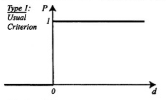

Usual Criterion

## STEP 2: Preference Function

Type 2: U-shape Criterion

\[P(d) = \begin{array}{cc} 0 \text{ if } d\leq q\\ 1 \text{ if } d>q \end{array}\]

Parameters:

q - threshold of indifference

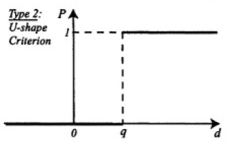

U-shape Criterion

## STEP 2: Preference Function

Type 3: V-shape Criterion

\[P(d) = \begin{array}{cc} 0 \text{ if } d\leq 0\\ {\frac{d}{p}} \text{ if } 0 < d\leq p\\ 1 \text{ if } d>p \end{array}\]

Parameters:

p - threshold of strict preference

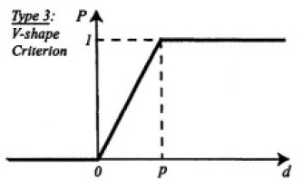

V-shape Criterion

## STEP 2: Preference Function

Type 4: Level Criterion

\[P(d) = \begin{array}{cc} 0 \text{ if } d\leq q\\ {\frac{1}{2}} \text{ if } q < d\leq p\\ 1 \text{ if } d>p \end{array}\]

Parameters:

q - threshold of indifference p - threshold of strict preference

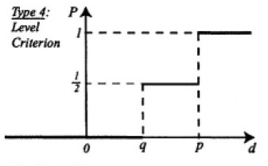

Level Criterion

## STEP 2: Preference Function

Type 5: V-shape with indifference Criterion

\[P(d) = \begin{array}{cc} 0 \text{ if } d\leq \text{q}\\ {\frac{d-q}{p-q}} \text{ if } q < d\leq p\\ 1 \text{ if } d>p \end{array}\]

Parameters:

q - threshold of indifference p - threshold of strict preference

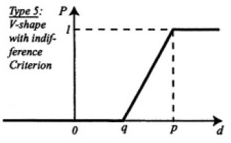

V-shape with indifference Criterion

## STEP 2: Preference Function

Type 6: Gaussian Criterion

Parameters:

s - an intermediate value between q and p

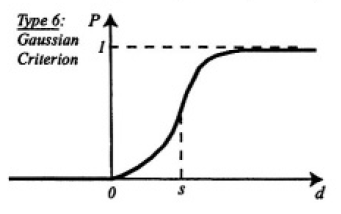

Gaussian Criterion

## STEP 2: Preference Function

Choosing the appropriate parameters is crucial, though easy

- **Indifference threshold (q)** is the largest deviation which is considered as negligible by the decision maker
- **Preference threshold (p)** is the smallest deviation which is considered as sufficient to generate a full preference
- **s** defines the inflection point of the preference function.
  - If s is close to q, preferences will be reinforced for small deviations,
  - If s is close to p, preferences will be softened for small deviations

## STEP 2: Pairwise Difference

| P1 | P2 | CurrencyRatio | CashRatio | LeverageRatio | AssetTurnover | ROA | ROC | NetProfitMargin |
| --- | --- | --- | --- | --- | --- | --- | --- | --- |
| ATLAS | ECBYO | -0.0171821305841924 | 0.285031399381386 | -0.775 | -0.352023121387283 | -0.78125 | -0.807453416149068 | -0.729508196721312 |
| ATLAS | ET YAT | -0.00687285223367695 | 0.395257287468366 | -0.9 | -0.572832369942196 | -0.9375 | -0.944099378881988 | -0.792349726775956 |
| ATLAS | EUKYO | -0.0335051546391752 | 0.392070484581498 | -0.0499999999999997 | 0.164739884393064 | -0.15625 | -0.093167701863354 | -0.128415300546448 |
| ATLAS | EUYO | -0.784364261168385 | -0.0134970475208548 | -0.5 | -0.0491329479768785 | -0.59375 | -0.447204968944099 | -0.519125683060109 |
| ATLAS | GRNYO | 0.215635738831615 | 0.192989033648889 | -0.675 | -0.18150289017341 | -0.6875 | -0.645962732919255 | -0.639344262295082 |
| ATLAS | ISYAT | -0.368556701030928 | 0.82641297216234 | -1 | -0.81271676300578 | -1 | -1 | -1 |
| ATLAS | OYAYO | -0.357388316151203 | -0.17358702783766 | -0.225 | 0.18728323699422 | -0.3125 | -0.198757763975155 | -0.278688524590164 |
| ATLAS | VKFYO | -0.300687285223368 | -0.0169650388977408 | -0.4 | -0.171098265895954 | -0.46875 | -0.335403726708075 | -0.420765027322404 |
| ECBYO | ATLAS | 0.0171821305841924 | -0.285031399381386 | 0.775 | 0.352023121387283 | 0.78125 | 0.807453416149068 | 0.729508196721312 |
| ECBYO | ET YAT | 0.0103092783505155 | 0.110225888086981 | -0.125 | -0.220809248554913 | -0.15625 | -0.136645962732919 | -0.0628415300546449 |

[output cut: 62 more lines]

## STEP 2: Preference Function

| P1 | P2 | CurrencyRatio | CashRatio | LeverageRatio | AssetTurnover | ROA | ROC | NetProfitMargin |
| --- | --- | --- | --- | --- | --- | --- | --- | --- |
| ATLAS | ECBYO | 0 | 1 | 0 | 0 | 0 | 0 | 0 |
| ATLAS | ET YAT | 0 | 1 | 0 | 0 | 0 | 0 | 0 |
| ATLAS | EUKYO | 0 | 1 | 0 | 1 | 0 | 0 | 0 |
| ATLAS | EUYO | 0 | 0 | 0 | 0 | 0 | 0 | 0 |
| ATLAS | GRNYO | 1 | 1 | 0 | 0 | 0 | 0 | 0 |
| ATLAS | ISYAT | 0 | 1 | 0 | 0 | 0 | 0 | 0 |
| ATLAS | OYAYO | 0 | 0 | 0 | 1 | 0 | 0 | 0 |
| ATLAS | VKFYO | 0 | 0 | 0 | 0 | 0 | 0 | 0 |
| ECBYO | ATLAS | 1 | 0 | 1 | 1 | 1 | 1 | 1 |
| ECBYO | ET YAT | 1 | 1 | 0 | 0 | 0 | 0 | 0 |

[output cut: 62 more lines]

## STEP 3: Aggregated Preference Function

The preference functions for criteria are aggregated by assigning weights. The aggregated preference function is given by:

\[\pi(a,b)=\sum_{j=1}^k P_j(a,b)w_j\] \[\pi(b,a)=\sum_{j=1}^k P_j(b,a)w_j\]

\(\pi(a,b)\) expresses with which degree \(a\) is preferred to \(b\) over all the criteria

\(\pi(b,a)\) expressses how \(b\) is preferred to \(a\)

## STEP 3: Aggregated Preference Function

| P1 | P2 | Aggregated_Preference |
| --- | --- | --- |
| ATLAS | ECBYO | 0.0407187713401979 |
| ATLAS | ET YAT | 0.0564653267811952 |
| ATLAS | EUKYO | 0.0795443384249374 |
| ATLAS | EUYO | 0 |
| ATLAS | GRNYO | 0.0583749674972149 |
| ATLAS | ISYAT | 0.118058996023191 |
| ATLAS | OYAYO | 0.0267547481420314 |
| ATLAS | VKFYO | 0 |
| ECBYO | ATLAS | 0.494630980691694 |
| ECBYO | ET YAT | 0.0172193094910709 |

[output cut: 62 more lines]

## STEP 3: Aggregated Preference Function

General properties of the aggregated preference function \(\pi(a,b)\) \[\pi(a,a)=0\] \[0\leq\pi(a,b)\leq 1\] \[0\leq\pi(b,a)\leq 1\] \[0\leq\pi(a,b)+\pi(b,a)\leq 1\]

\(\pi(a,b)\) close to 0 implies a is weakly preferred over b

\(\pi(a,b)\) close to 1 implies a is strongly preferred over b

## STEP 4: Outranking Flows

- Each alternative \(a\) faces \(n-1\) other alternatives

\(\implies\) \(n-1\) pairs \(\pi(a,b)\) for any \(a\in A\).

We take their average to get outranking flows

**Positive outranking flow** of a \(\phi^+(a)\)  
- The power or outranking character of \(a\)  
- Average of \(\pi(a,x)\) for each \(x\neq a\)

\[\rightarrow \phi^+(a) = \frac1{n-1} \sum_{x\in A}\pi(a,x)\]

- It expresses how an alternative is outranking all the others
- The higher \(\phi^+(a)\), the better the alternative

## STEP 4: Positive Outranking Flows

| Fund | CurrencyRatio | CashRatio | LeverageRatio | AssetTurnover | ROA | ROC | NetProfitMargin |
| --- | --- | --- | --- | --- | --- | --- | --- |
| ATLAS | 0.12 | 0.62 | 0 | 0.25 | 0 | 0 | 0 |
| ECBYO | 0.38 | 0.38 | 0.75 | 0.75 | 0.75 | 0.75 | 0.75 |
| EUKYO | 0.12 | 0.12 | 0.88 | 0.88 | 0.88 | 0.88 | 0.88 |
| EUYO | 0.5 | 0.12 | 0.12 | 0.12 | 0.12 | 0.12 | 0.12 |
| ET YAT | 1 | 0.75 | 0.5 | 0.38 | 0.5 | 0.5 | 0.5 |
| GRNYO | 0 | 0.5 | 0.62 | 0.62 | 0.62 | 0.62 | 0.62 |
| ISYAT | 0.88 | 0 | 1 | 1 | 1 | 1 | 1 |
| OYAYO | 0.75 | 1 | 0.25 | 0 | 0.25 | 0.25 | 0.25 |
| VKFYO | 0.62 | 0.75 | 0.38 | 0.5 | 0.38 | 0.38 | 0.38 |

## STEP 4: Negative Outranking Flows

**Negative outranking flow** of a \(\phi^-(a)\)  
- The weakness or outranked character of \(a\)  
- Average of \(\pi(x,a)\) for each \(x\neq a \rightarrow\) \[\phi^-(a) = \frac1{n-1} \sum_{x\in A}\pi(x,a)\]

- It expresses how an alternative is outranked by all the others
- The lower \(\phi^-(a)\), the better the alternative

## STEP 4: Negative Outranking Flows

| Fund | CurrencyRatio | CashRatio | LeverageRatio | AssetTurnover | ROA | ROC | NetProfitMargin |
| --- | --- | --- | --- | --- | --- | --- | --- |
| ATLAS | 0.75 | 0.38 | 1 | 0.75 | 1 | 1 | 1 |
| ECBYO | 0.62 | 0.62 | 0.25 | 0.25 | 0.25 | 0.25 | 0.25 |
| EUKYO | 0.75 | 0.75 | 0.12 | 0.12 | 0.12 | 0.12 | 0.12 |
| EUYO | 0.5 | 0.75 | 0.88 | 0.88 | 0.88 | 0.88 | 0.88 |
| ET YAT | 0 | 0.12 | 0.5 | 0.62 | 0.5 | 0.5 | 0.5 |
| GRNYO | 1 | 0.5 | 0.38 | 0.38 | 0.38 | 0.38 | 0.38 |
| ISYAT | 0.12 | 1 | 0 | 0 | 0 | 0 | 0 |
| OYAYO | 0.25 | 0 | 0.75 | 1 | 0.75 | 0.75 | 0.75 |
| VKFYO | 0.38 | 0.12 | 0.62 | 0.5 | 0.62 | 0.62 | 0.62 |

## STEP 5: Partial Ranking PROMETHEE I

- PROMETHEE I is the intersection of both positive and negative outranking flows

\[aPb \text{ iff } \begin{array}{cc} \phi^+(a)>\phi^+(b) \text{ & } \phi^-(a)\leq\phi^-(b)\\ \phi^+(a)\geq\phi^+(b) \text{ & } \phi^-(a)<\phi^-(b) \end{array}\]

\[aIb \text{ iff } \phi^+(a)=\phi^+(b) \text{ & } \phi^-(a)=\phi^-(b) \]

\[aRb \text{ iff } \begin{array}{cc} \phi^+(a)>\phi^+(b) \text{ & } \phi^-(a)>\phi^-(b) \\ \phi^+(a)<\phi^+(b) \text{ & } \phi^-(a)<\phi^-(b) \end{array}\]

## STEP 5: Partial Ranking PROMETHEE I

| alternative_a | alternative_b | phi_a_plus | phi_a_minus | phi_b_plus | phi_b_minus | positive_condition | negative_condition | partial_ranking |
| --- | --- | --- | --- | --- | --- | --- | --- | --- |
| ATLAS | ECBYO | 0.05 | 0.4 | 0.25 | 0.09 | ECBYO | ECBYO | ECBYO Preferred |
| ATLAS | ET YAT | 0.05 | 0.4 | 0.24 | 0.13 | ET YAT | ET YAT | ET YAT Preferred |
| ATLAS | EUKYO | 0.05 | 0.4 | 0.33 | 0.08 | EUKYO | EUKYO | EUKYO Preferred |
| ATLAS | EUYO | 0.05 | 0.4 | 0.02 | 0.4 | ATLAS | EUYO | Incomparable |
| ATLAS | GRNYO | 0.05 | 0.4 | 0.18 | 0.15 | GRNYO | GRNYO | GRNYO Preferred |
| ATLAS | ISYAT | 0.05 | 0.4 | 0.45 | 0.11 | ISYAT | ISYAT | ISYAT Preferred |
| ATLAS | OYAYO | 0.05 | 0.4 | 0.13 | 0.27 | OYAYO | OYAYO | OYAYO Preferred |
| ATLAS | VKFYO | 0.05 | 0.4 | 0.15 | 0.16 | VKFYO | VKFYO | VKFYO Preferred |
| ECBYO | ET YAT | 0.25 | 0.09 | 0.24 | 0.13 | ECBYO | ECBYO | ECBYO Preferred |
| ECBYO | EUKYO | 0.25 | 0.09 | 0.33 | 0.08 | EUKYO | EUKYO | EUKYO Preferred |

[output cut: 26 more lines]

## STEP 5: Partial Ranking PROMETHEE I

- Remember \(\phi_+(a)\) is power of a and \(\phi_-(a)\) is weakness of a
- a is preferred to b if a has higher power and/or lower weakness than b
- a and b are indifferent if both power and weakness are same
- a and b are incomparable if a has higher power and higher weakness or vice versa
  - Information provided by both flows is not consistent
  - Deciding which alternative is better is upto the decision-maker

## STEP 5: Complete Ranking PROMETHEE II

- PROMETHEE II is the balance between positive and negative outranking flows

\[\phi(a) = \phi^+(a) - \phi^-(a)\]  
- \(\phi(a)\) is the net outranking flow, with the following properties

\(-1 \leq \phi(a) \leq 1\) and \(\sum_ {x\in A} \phi(a) =0\) where

- \(\phi(a) > 0 \implies\) a is more outranking all alternatives
- \(\phi(a) < 0 \implies\) a is more outranked by other alternatives

The higher the net flow, the better the alternative

## STEP 5: Complete Ranking PROMETHEE II

| Fund | Entering_Flow | Leaving_Flow | Net_Flow | Rank |
| --- | --- | --- | --- | --- |
| ATLAS | 0.14 | 0.84 | -0.7 | 9 |
| ECBYO | 0.64 | 0.36 | 0.29 | 3 |
| EUKYO | 0.66 | 0.3 | 0.36 | 2 |
| EUYO | 0.17 | 0.81 | -0.63 | 8 |
| ET YAT | 0.59 | 0.39 | 0.2 | 4 |
| GRNYO | 0.51 | 0.49 | 0.03 | 5 |
| ISYAT | 0.84 | 0.16 | 0.68 | 1 |
| OYAYO | 0.39 | 0.61 | -0.21 | 7 |
| VKFYO | 0.48 | 0.5 | -0.01 | 6 |

## STEP 5: Complete Ranking PROMETHEE II

- No incomparabilities remain, but more information gets lost by considering the difference
- \(\phi(a)\) relies on comparative statements rather than absolute statements
- Recommended to use PROMETHEE I an II together for more information

## GAIA

| Fund | CurrencyRatio | CashRatio | LeverageRatio | AssetTurnover | ROA | ROC | NetProfitMargin |
| --- | --- | --- | --- | --- | --- | --- | --- |
| ATLAS | -0.2 | 0.24 | -0.57 | -0.23 | -0.62 | -0.56 | -0.56 |
| ECBYO | -0.19 | -0.08 | 0.31 | 0.18 | 0.26 | 0.35 | 0.26 |
| EUKYO | -0.2 | -0.21 | 0.45 | 0.42 | 0.44 | 0.49 | 0.32 |
| EUYO | -0.17 | -0.21 | -0.51 | -0.42 | -0.44 | -0.46 | -0.41 |
| ET YAT | 0.68 | 0.25 | 0 | -0.17 | 0.05 | -0.05 | 0.02 |
| GRNYO | -0.45 | 0.02 | 0.2 | -0.02 | 0.16 | 0.17 | 0.15 |
| ISYAT | 0.21 | -0.69 | 0.56 | 0.69 | 0.51 | 0.57 | 0.56 |
| OYAYO | 0.19 | 0.43 | -0.32 | -0.44 | -0.27 | -0.33 | -0.25 |
| VKFYO | 0.14 | 0.25 | -0.11 | -0.03 | -0.09 | -0.18 | -0.09 |

## GAIA

[figure not shown]

## GAIA

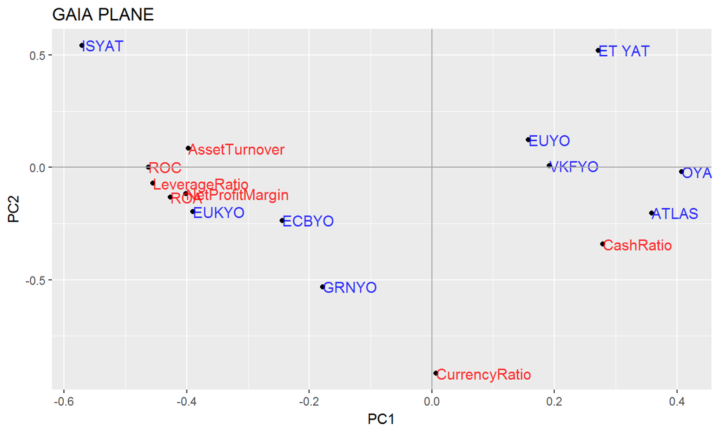